# Advanced Moderated Mediation Analysis

Conditional Process Analysis: Hayes PROCESS Models 7, 8, and 59  
Pick-a-Point Probing & Johnson-Neyman Technique

Statistics for Social Work · March 31, 2026

**X** Violence Exposure

**M** PTSS (Trauma Symptoms)

**Y** Delinquency

**W** Sex (Moderator)

Applied Example

# Visualizing Moderation with processR

## A Worked Example: Climate Change Framing & Justification

**X** frame  
Climate vs. Natural causes

**W** skeptic  
Climate skepticism (continuous)

**Y** justify  
Justification of inaction

This example uses the `disaster` dataset from Hayes (2022) and walks through Hayes Model 1 — simple moderation — using the R package **processR**.

processR Example — Step 1

## Conceptual Model: Frame → Justify, Moderated by Skepticism

We begin by defining our variable labels and plotting the **conceptual diagram**. This is the big-picture view: X affects Y, with W moderating that relationship.

```
library(processR)
library(lavaan)

# Fit the moderation model
fit <- lm(justify ~ frame * skeptic,
           data = disaster)

# Define labels for diagrams
labels <- list(X = "frame",
               W = "skeptic",
               Y = "justify")

# Plot conceptual model (Model 1)
pmacroModel(1, labels = labels)
```

What This Shows

The conceptual model places **skeptic (W)** as a moderator on the path from **frame (X)** to **justify (Y)**. No mediator — this is pure moderation (Hayes Model 1).

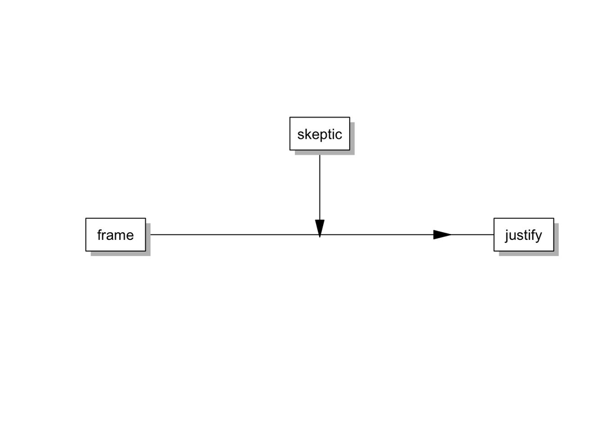

Fig 1. Conceptual model — W (skeptic) moderates the X→Y path

processR Example — Step 2

## Statistical Model: Unpacking the Regression Equation

The **statistical diagram** shows the regression equation explicitly. Three predictors enter the model: X, W, and their product X×W.

```
statisticalDiagram(1, labels = labels)
```

Model 1 Equation

*justify* = i + b<sub>1</sub>(frame) + b<sub>2</sub>(skeptic) + b<sub>3</sub>(frame×skeptic) + e

Key Insight

b<sub>3</sub> is the interaction coefficient. If significant, it tells us the effect of *frame* on *justify* **changes depending on how skeptical** the respondent is. This is the core of moderation.

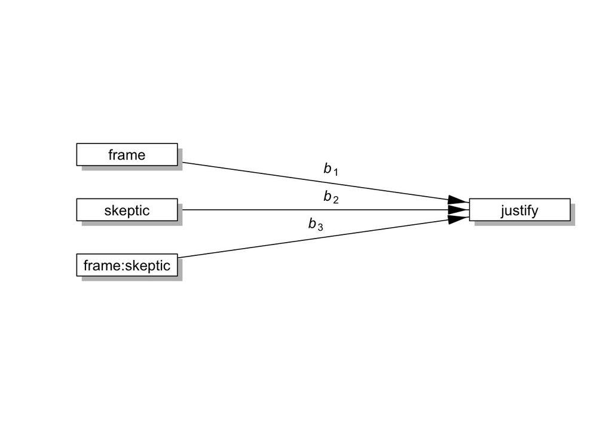

Fig 2. Statistical diagram — three antecedents, three coefficients

processR Example — Step 3

## Model Summary: Reading the Coefficients

```
modelsSummaryTable(list(fit), labels = labels)
```

| Antecedent |  | Coef | SE | t | p |
| --- | --- | --- | --- | --- | --- |
| X | frame | -0.562 | 0.218 | -2.581 | .011 |
| W | skeptic | 0.105 | 0.038 | 2.756 | .006 |
| X×W | frame:skeptic | 0.201 | 0.055 | 3.640 | <.001 |
| Constant |  | 2.452 | 0.149 | 16.449 | <.001 |
| R² |  | 0.246 \| Adj. R² = 0.235 \| F(3,207) = 22.543, p < .001 |  |  |  |

The Interaction (b<sub>3</sub> = 0.201)

Significant at p < .001. This confirms moderation: the effect of framing on justification **varies as a function of climate skepticism**. We must now probe this interaction to understand its shape.

What b<sub>1</sub> = −0.562 Means (Alone)

processR Example — Step 4

## Probing the Interaction: Conditional Effect Plots

```
# Pick-a-point plot at 3 W values
condPlot(fit, rangemode = 2, xpos = 0.7,
  labels = c("Climate change (X=1)",
             "Natural causes (X=0)"))
```

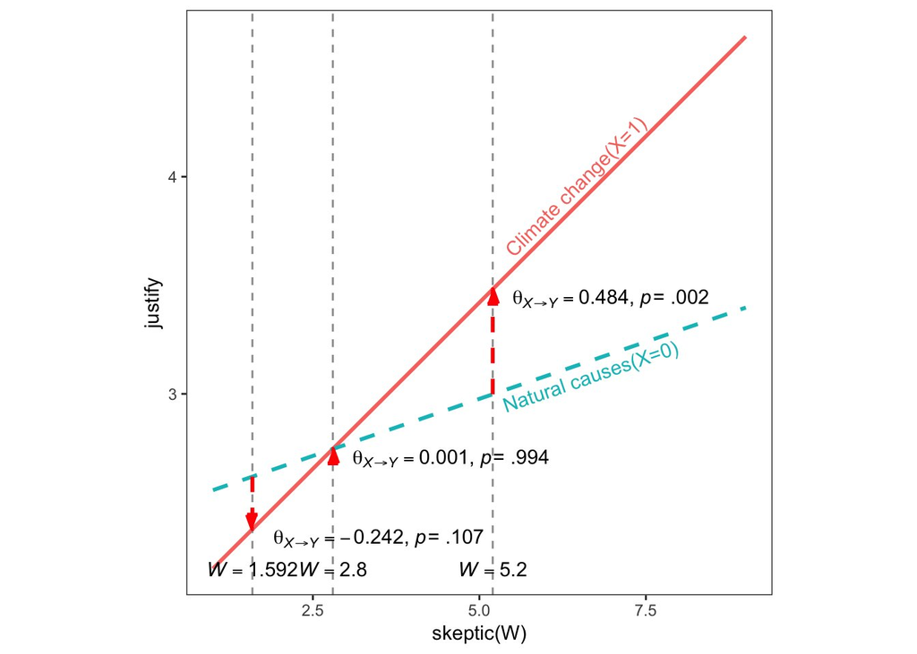

Fig 3. Conditional effect of X on Y at three W levels. At low skepticism the climate frame *reduces* justification; at high skepticism it *increases* it.

```
# Regression lines by frame condition
condPlot(fit, mode = 2, xpos = 0.6)
```

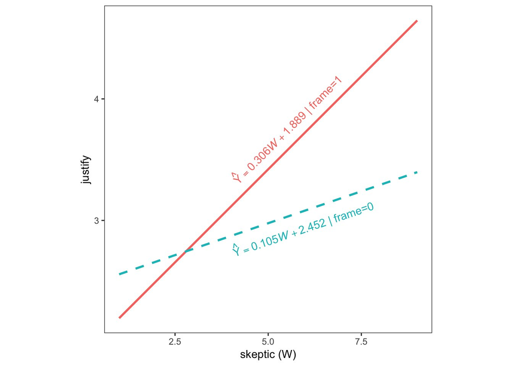

Fig 4. Regression lines show the climate-change frame group (X=1) has a steeper slope, diverging from the natural-causes group as skepticism increases.

processR Example — Fig 3 Deep Dive

## Reading the Two-Line Conditional Effect Plot

This figure is produced by `condPlot(fit, rangemode=2)`. It shows the predicted value of *justify* on the y-axis, plotted against *skeptic* (W) on the x-axis, separately for the two framing conditions.

What the Two Lines Mean

- **Red line (X=1, Climate frame)**: predicted justification for people told climate change caused the drought, across the range of skepticism
- **Teal line (X=0, Natural causes)**: predicted justification for people given no climate cause, across the same range

The Key Visual Signal: Non-Parallel Lines

If the lines were **parallel**, there is no moderation — framing has the same effect regardless of skepticism. Non-parallel lines = moderation. Crossing lines = crossover interaction: the framing effect *reverses* direction across the range of W.

Reading Each Zone

- **Left side (low skepticism, W≈1.6)**: Lines are close or the climate line is *lower* than natural-causes — among believers, climate framing slightly reduces justification of inaction. The gap is small and not significant.
- **Middle (W≈2.8)**: Lines cross — the crossover point. Climate frame and natural-cause frame produce virtually identical justification scores.
- **Right side (high skepticism, W≈5.2)**: The climate line is *above* the natural-causes line — among skeptics, climate framing sharply *increases* justification of withholding aid.

Common Misreading

Do NOT read the height of each line as "the effect." The height is the *predicted outcome*. The *effect* of X is the **vertical gap between the lines at any given W value**. That gap is what the next figure (conditional effect plot) puts on the y-axis directly.

processR Example — Fig 4 Deep Dive

## Reading the Regression Lines by Frame Condition

This is the same model shown differently. `condPlot(fit, mode=2)` draws the **regression line for each frame condition** as a function of skepticism. The slope of each line tells you how skepticism relates to justification within that framing group.

The Two Regression Lines

When X=1 (Climate frame): justify = (i + c₁) + (c₂ + c₃)·W  
When X=0 (Natural causes): justify = i + c₂·W

Slope Interpretation

Both lines have positive slopes: as skepticism increases, justification increases in both conditions. But the **climate-frame slope is steeper** — skepticism matters MORE when the drought is attributed to climate change.

Why Two Figures for the Same Model?

Fig 3 emphasizes *where the difference between conditions is significant* (vertical gap). Fig 4 emphasizes *the underlying regression equations* (slopes and intercepts). They show the same interaction from two complementary angles:  
• Fig 3 answers: *At which levels of W does framing matter?*  
• Fig 4 answers: *How does skepticism relate to justification, within each frame?*

What Steeper Slope Means Substantively

Among people who received the climate-change frame, skepticism is a much stronger predictor of willingness to withhold aid. Among those who received the natural-causes frame, skepticism also predicts justification, but less powerfully. The frame does not *create* the effect of skepticism — it *amplifies* it.

processR Example — Step 5

## Conditional Effect of Frame on Justify Across Skepticism

```
condPlot(fit, mode = 3, rangemode = 2,
         xpos = 0.5, ypos = c(0, 2))
```

This plot re-expresses the interaction as the **conditional effect** θ<sub>X→Y</sub> on the Y-axis — how much the frame matters, across the range of skepticism.

Reading the Three Pick-a-Point Values

- W = 1.592 (16th %ile): θ = −0.242, p = .107 — not significant
- W = 2.800 (50th %ile): θ = 0.001, p = .994 — no effect
- W = 5.200 (84th %ile): θ = 0.484, p = .002 — significant

Substantive Interpretation

Framing only *matters* for high skeptics. Among those who already doubt climate science, a climate-change frame significantly increases justification of inaction.

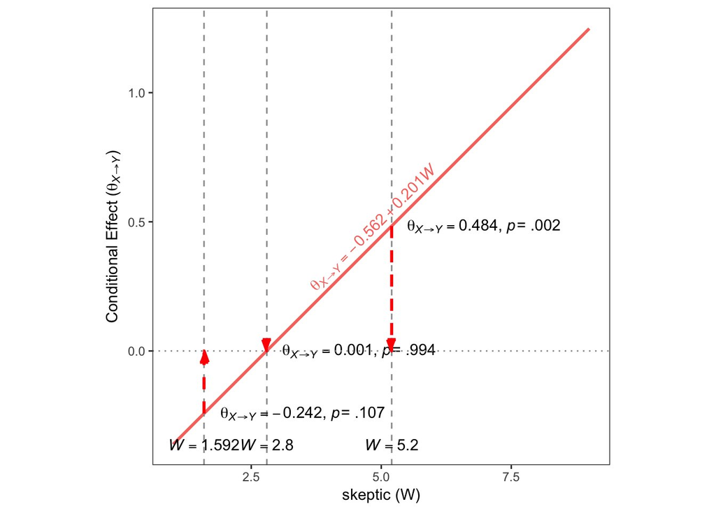

processR Example — Conditional Effect Explained

## What the f(W) Line Shows: Reading the Continuous Effect Plot

This is the most important figure in the pick-a-point analysis. The y-axis is now the **conditional effect of X on Y** (θ<sub>X→Y</sub>), not the predicted outcome. The x-axis is still the moderator.

The Line You See

θ<sub>X→Y</sub> = c₁ + c₃·W = −0.562 + 0.201·W  
This is a *linear function* of W. For every 1-unit increase in skepticism, the effect of climate framing on justification increases by 0.201 units.

The Three Pick-a-Point Dots

The three highlighted points correspond to W at the 16th, 50th, and 84th percentiles — the standard "representative values" used in pick-a-point probing. These are not arbitrary choices; they span roughly the central 68% of the W distribution.

The Confidence Band: Your Significance Guide

Key Reading: Where Does the Band Cross Zero?

processR Example — Pick-a-Point Deep Dive

## Interpreting the Three Conditional Effect Values

Low Skepticism (W=1.59, 16th %ile)

θ<sub>X→Y</sub> = **−0.242**, p = .107

For people with low climate skepticism, the climate-change frame *slightly reduces* justification of inaction compared to the natural-causes frame. However, this difference is not statistically significant — we cannot rule out that it is zero.

**In plain language:** Among climate believers, framing doesn't change behavior much — they already have a strong internal response to climate information.

Moderate Skepticism (W=2.80, 50th %ile)

θ<sub>X→Y</sub> = **0.001**, p = .994

At the median of skepticism, the effect of framing is essentially *zero*. Climate frame and natural-causes frame produce nearly identical justification scores. This is the **crossover point** — the exact value of W where the two regression lines intersect.

**In plain language:** For "average" skeptics, how the drought is framed doesn't move the needle.

High Skepticism (W=5.20, 84th %ile)

θ<sub>X→Y</sub> = **+0.484**, p = .002

For high skeptics, the climate-change frame *significantly increases* justification of withholding aid. Telling a climate skeptic that a famine was caused by climate change makes them *more* willing to withhold aid, not less.

**In plain language:** Climate framing backfires with skeptics — it increases their justification for inaction by nearly half a point on the scale.

💡 The Substantive Finding

Climate-change framing **does not universally increase concern**. Among believers it may slightly reduce justification for inaction (positive effect), but among skeptics it significantly *increases* justification. The same message produces opposite effects depending on the audience.

processR Example — Step 6

## Johnson-Neyman Plot: Where Does the Effect Become Significant?

```
jnPlot(fit, plot = FALSE)

# Output:
# JOHNSON-NEYMAN INTERVAL
# When skeptic is OUTSIDE [1.171, 3.934],
# the slope of frame is p < .05.
# Range of observed skeptic: [1.000, 9.000]
```

J-N Transition Points

The effect of framing is non-significant for skeptic values between 1.171 and 3.934. Below W = 1.171 (very low skepticism) the frame *significantly reduces* justification; above W = 3.934 it *significantly increases* it.

Why This Matters

Unlike pick-a-point, J-N gives you the **exact threshold** in the moderator's metric. You can report: “For participants scoring above 3.93 on climate skepticism, framing significantly increased justification of inaction (p < .05).”

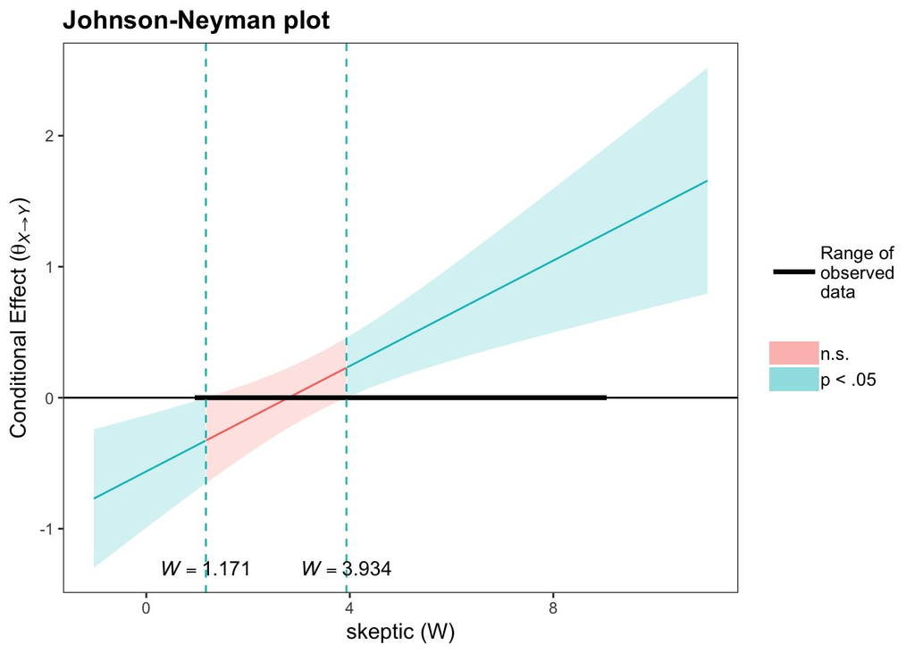

processR Example — J-N Deep Dive (1 of 2)

## How to Read the Johnson-Neyman Plot

The J-N plot is built on the same conditional effect line as the previous figure — but now the shading directly marks zones of significance:

Zone Reading

The Two J-N Thresholds

Below W = 1.171: effect is significant (negative direction)  
Between 1.171 and 3.934: NOT significant  
Above W = 3.934: effect is significant (positive direction)

💡 What Makes J-N Better Than Pick-a-Point?

Pick-a-point tells you significance at *three pre-chosen values* (16th, 50th, 84th %ile). J-N tells you significance at *every value of W* and gives you the exact threshold in the original metric of W.  
Instead of saying "the effect is significant at W=5.2," you can say:  
**"For all participants scoring above 3.93 on the skepticism scale, the climate-change frame significantly increased justification of inaction (p < .05)."**

Coverage: How Many People Are in Each Zone?

The range of observed skepticism is 1.0 to 9.0. The threshold W=3.934 is at approximately the 65th percentile. So about **35% of the sample** is in the significant positive zone — and these are the participants for whom the framing effect is real and meaningful.

processR Example — J-N Deep Dive (2 of 2)

## Reporting J-N Results: The Language to Use

Standard J-N Report Language

Do NOT Report This Way

"The moderation was significant for skeptics." This is vague and meaningless. J-N gives you a *precise threshold in the original metric*. Use it.

💡 Pick-a-Point vs. J-N: When to Use Which

**Use Pick-a-Point when:**  
• Your moderator has meaningful, interpretable levels (e.g., 16th = "low trauma", 84th = "high trauma")  
• You want effect sizes at specific theoretically-relevant points  
• You plan to visualize a 2×2 pattern  
**Use J-N when:**  
• You want to report the exact boundary where significance switches  
• Your moderator is purely continuous with no natural reference points  
• You want to communicate what percentage of the sample is in each zone

Using Both Together

Hayes recommends reporting *both*. Pick-a-point gives interpretable effect sizes at representative values. J-N provides the precise boundary. Together they give readers a complete picture of how the effect varies across W.

processR Example — Step 7

## SEM Estimation & Final Statistical Diagram with Estimates

```
moderator <- list(name = "skeptic",
                  site = list("c"))
model <- tripleEquation(labels = labels,
                        moderator = moderator)

semfit <- sem(model = model, data = disaster)

# Final diagram with coefficients
statisticalDiagram(1, labels = labels,
                   fit = semfit,
                   whatLabel = "est")
```

Defined Parameters (from lavaan)

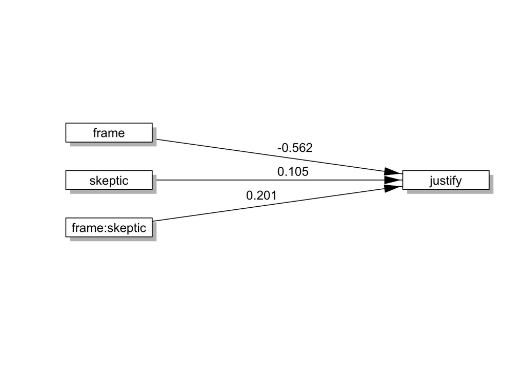

processR Example — Final Diagram Explained

## Reading the Fully Labeled Statistical Diagram

The Three Paths from Antecedents

💡 The Defined Parameters from lavaan

What to Include in Your Diagram

All coefficient labels (c₁, c₂, c₃), asterisks for significance levels (* p<.05, ** p<.01, *** p<.001), R² for the equation, and the sample size. Reviewers expect all of this. A path diagram without labeled coefficients is incomplete.

processR Example — Complete Workflow

## The 7-Step processR Workflow: Quick Reference

| Step | What You Do | What You Get | Key Question It Answers |
| --- | --- | --- | --- |
| **1** | Define labels, fit lm(), plot conceptual model | Big-picture diagram (X→Y, W on path) | Is my theory correctly diagrammed? |
| **2** | statisticalDiagram() | Regression equation as a diagram | Do I have the right number of antecedents? |
| **3** | modelsSummaryTable() | Coefficient table with SE, t, p | Is the interaction significant? |
| **4** | condPlot(mode=1 & 2) | Two-line plot + regression lines | In which direction does the interaction run? |
| **5** | condPlot(mode=3) | f(W) with CI band | At which W values is the effect significant? |
| **6** | jnPlot() | J-N thresholds | What is the exact W boundary for significance? |
| **7** | tripleEquation() + sem() + statisticalDiagram(fit) | Final labeled path diagram | What coefficients do I report in my paper? |

💡 This Workflow Applies to Models 7, 8, and 59

The steps are identical. Only the number of equations and interaction terms changes. Every figure you just learned to read — the two-line plot, the f(W) plot, the J-N plot, the final diagram — appears in all three models. You will use this workflow for your dissertation.

Today’s Class

## What We Will Cover

Model 7

- First-stage moderation only
- W moderates the *a*-path
- *b*-path is constant
- Trauma sensitivity differs; behavioral response does not

Model 8

- Dual moderation
- W moderates *a*-path AND direct *c′*-path
- Two interaction terms in two equations
- Mediated AND direct paths both vary by W

Model 59

- Full conditional process
- W moderates *a*, *b*, and *c′*
- Quadratic indirect effect
- Every causal link is contingent on W

Core Question

We move beyond "Does it work?" to **"For whom, through what mechanism, and under what conditions?"**

New Today

**Pick-a-Point probing** (16th/50th/84th percentile logic) and the **Johnson-Neyman technique** — when to use each and how to interpret them.

Motivation

## Why Moderated Mediation Matters for Social Work Practice

- **Universal interventions fail marginalized groups**: An average treatment effect of zero can hide a strong benefit for one group and harm for another — moderated mediation reveals this
- **Mechanism ≠ universal**: The *same* exposure can operate through completely different psychological processes depending on identity, context, or biology
- **Policy precision**: Knowing W defines who needs what intervention. "Trauma-informed care works — for boys who have low social support" is actionable. "It works on average" is not.
- **Ethical obligation**: Reporting only average effects can obscure differential harm. PhD-level social work researchers are obligated to report heterogeneity.

Real Example

A school-based trauma intervention showed no average effect in an RCT. Moderated mediation revealed it worked strongly for girls (through emotion regulation) but had no effect for boys. The program was being discontinued. The conditional analysis saved it — and redesigned the boys’ component.

The Precision Medicine Analogy

We don’t prescribe the same medication dose to all patients. We shouldn’t prescribe the same intervention to all children. Moderated mediation is the statistical equivalent of precision medicine.

Before You Run the Model

## Data Requirements & Key Assumptions

- **Sample size**: Conditional process models are power-hungry. For Model 7 with bootstrapping, aim for N ≥ 200. Model 59 needs N ≥ 400–500 to detect moderate quadratic indirect effects with adequate power (Fritz & MacKinnon, 2007)
- **Linearity**: Assumes linear relationships between all variables. Inspect scatterplots of X–M and M–Y. Non-linearity biases interaction estimates
- **Measurement reliability**: Unreliable measures attenuate interaction effects — interaction terms are among the first things eaten by measurement error
- **Multicollinearity**: Interaction terms (X×W) correlate highly with their constituent variables. Check VIF after computing the product term. VIF > 10 is a problem
- **Normal errors**: OLS assumptions still apply to each regression equation; bootstrapping corrects for non-normal sampling distributions of indirect effects, not for non-normal residuals

The Bootstrapping Misconception

Bootstrapping does **not** fix small samples — it provides more accurate CIs for the sampling distribution of a product. With N < 100, even bootstrapped CIs are unreliable. Power analysis before data collection is non-negotiable.

PROCESS Requirement

PROCESS requires complete cases by default. Missing data on any variable drops the entire row. Use multiple imputation (MICE in R or SPSS) before running PROCESS if missingness > 5%.

Before You Run the Model

## Centering X and W: What, Why, and How

- **What centering is**: Subtracting the mean from each variable before computing the product term (X×W). Mean-centered X and W have means of zero.
- **Why it matters**: Without centering, the main effect of X (a₁) is estimated at W = 0, which may be a nonsensical or non-existent value of W. After centering, a₁ = effect of X at the *mean* of W — meaningful and interpretable.
- **It does NOT change the interaction**: The a₃ coefficient, its SE, and p-value are identical whether you center or not. Only the main effects and intercept change.
- **Standardized vs. mean-centered**: Standardizing (z-scoring) W also works — then percentiles map directly to SD units. PROCESS does this automatically if you choose standardized output.
- **Binary moderators**: If W is 0/1 (e.g., sex), no centering needed. The main effect of X is simply the effect for the W=0 group.

Without centering — a₁ is X effect when W literally = 0

M = i + a₁X + a₂W + a₃(X×W) + e

With centering — a₁ is X effect at average W (interpretable)

M = i + a₁X<sub>c</sub> + a₂W<sub>c</sub> + a₃(X<sub>c</sub>×W<sub>c</sub>) + e

PROCESS Tip

PROCESS has a built-in centering option. In the dialog: Options → Mean center for products. Always enable this unless you have a specific reason not to (e.g., W has a meaningful zero like age in months from birth).

Conceptual Foundation

## Mediation, Moderation, and Conditional Process

- **Mediation** explains the *mechanism*: Violence → PTSS → Delinquency. M is the “why.”
- **Moderation** identifies *boundary conditions*: Does Sex change the strength of any path?
- **Conditional Process** — both simultaneously. The mechanism itself varies across values of W.
- **Goal** — demographic-aware intervention science that identifies *for whom* and *under what conditions* effects operate.

In Plain Language

W is the “lens.” The same violence exposure can produce different trauma, and that trauma can drive different behavior, depending on who we are studying.

[figure not shown]

Key Concept

## The Indirect Effect as a Function: *f*(W)

- In simple mediation, the indirect effect is one number: ab
- In moderated mediation, it becomes a *function of the moderator*: the indirect effect changes depending on W
- Notation: f(W) = θ<sub>M|X</sub> × θ<sub>Y|M</sub>
- Think of a bridge: its strength changes as W (sex, support, context) changes
- We probe this function at specific W values — using Pick-a-Point or Johnson-Neyman

Why it matters

A single indirect effect estimate hides who is affected most. *f*(W) reveals the full picture.

Example

In Model 7 (Violence → PTSS → Delinquency, moderated by Sex): f(W) = (a<sub>1</sub> + a<sub>3</sub>W) × b. The indirect effect is **different for boys and girls** — not a single number but a conditional one.

Key Concept · Visualized

## f(W): How the Indirect Effect Varies Across the Moderator

Reading this graph

At W=0 (female), the indirect effect is 0.23. At W=1 (male), it is 0.39. The slope of the line shows how the indirect effect changes across values of W.

How We Probe f(W)

**Pick-a-Point**: Evaluate f(W) at 16th, 50th, 84th percentiles of W — reporting conditional indirect effects at three representative values.  
**Johnson-Neyman**: Find the exact value of W where f(W) transitions from non-significant to significant.

Section 1 of 4

# Model 7

## First-Stage Moderation

W moderates the **a-path** only · The b-path is constant across W

Model 7 · Structural Equations

## The Two Regression Equations

Mediator Equation (M model) — interaction appears HERE

M = i<sub>M</sub> + a<sub>1</sub>X + a<sub>2</sub>W + **a<sub>3</sub>(X×W)** + e<sub>M</sub>

Outcome Equation (Y model) — no interaction, b is constant

Y = i<sub>Y</sub> + c′X + **b**M + e<sub>Y</sub>

- **a<sub>3</sub>** is the critical interaction term — it measures how much the X→M slope changes per unit of W
- **b** has no subscript — the M→Y relationship is identical for all values of W
- The conditional indirect effect is: (a<sub>1</sub> + a<sub>3</sub>W) × b
- This is a *linear function of W* — it grows or shrinks proportionally

When to use Model 7

When your theory says W changes *trauma sensitivity* (how much X creates M), but that once traumatized, everyone responds to trauma with the same behavioral outcomes.

Model 7 · PROCESS Output

## Reading the M-Model Table

```
MODEL 7 · OUTCOME: M (PTSS)
──────────────────────────────────────────────────────────────────────
           coeff       se        t        p       LLCI     ULCI
──────────────────────────────────────────────────────────────────────
constant   1.2403    .1542     8.043    .0000    .9365    1.5441
Violence   0.4521    .0642     7.042    .0000    .3256     .5786   ← a1
Sex       -0.1203    .1203    -1.000    .3183   -.3572     .1166
Int_1      0.3142    .0821     3.827    .0002    .1524     .4760   ← a3 (KEY)
──────────────────────────────────────────────────────────────────────
Product term: Int_1 = Violence × Sex
```

- Int_1 = 0.31, p = .0002 — the interaction is significant; the a-path varies by sex
- Sex alone (p = .32) — not a main-effect predictor of PTSS
- Violence main effect (p < .001) — universally significant

In Plain Language

For every unit increase in the moderator (female=0 to male=1), the slope of Violence on PTSS increases by 0.31. Violence becomes more traumatizing for boys. The response to violence is not universal.

Model 7 · Bootstrap Results

## Conditional Indirect Effects: Violence → PTSS → Delinquency

| Group (W) | Effect Estimate | BootSE | BootLLCI | BootULCI | Significant? |
| --- | --- | --- | --- | --- | --- |
| Females (W=0) | 0.232 | .052 | .132 | .342 | Yes (excl. 0) |
| Males (W=1) | 0.393 | .068 | .261 | .531 | Yes (excl. 0) |

Females

0.23

Males

0.39

In Plain Language

Neither CI includes zero → both effects are real. The indirect path through trauma is **70% stronger for boys**. Same violence exposure, very different outcome trajectories.

Note on Significance

For indirect effects, **always** use Bootstrap CIs, not p-values. The indirect effect is a *product* of two coefficients and is not normally distributed. Standard errors from Sobel tests are biased.

Probing Methods

# How Do We Probe Conditional Effects?

## Pick-a-Point & Johnson-Neyman

Two complementary approaches to understanding *where* and *for whom* effects are significant

Probing Methods · Pick-a-Point

## Pick-a-Point: Why the 16th, 50th, and 84th Percentile?

- **The problem**: When W is continuous (e.g., trauma score, support scale), we cannot report effects for every possible value of W
- **The solution**: Report conditional effects at three strategically chosen “representative” values
- **Mean ± 1SD rule**: For a normally distributed W, the 16th percentile ≈ mean − 1SD, the 84th ≈ mean + 1SD
- **Why these?** They span the most common range of W values (roughly 68% of participants fall between them) without going to extremes
- **Centered interpretation**: The 50th percentile (median/mean) is the “average person” condition

Why Not Mean±1SD Directly?

Using exact percentiles is more robust when W is skewed or non-normal. PROCESS reports these automatically. For binary W (like sex), just use the two groups.

Section 2 of 4

# Model 8

## Dual Moderation

W moderates **the a-path AND the direct c′-path**

Model 8 · Structural Equations

## Both Equations Now Contain W

Mediator Equation (same as Model 7)

M = i<sub>M</sub> + a<sub>1</sub>X + a<sub>2</sub>W + **a<sub>3</sub>(X×W)** + e<sub>M</sub>

Outcome Equation — NEW: direct path is now also moderated

Y = i<sub>Y</sub> + c′<sub>1</sub>X + c′<sub>2</sub>W + **c′<sub>3</sub>(X×W)** + bM + e<sub>Y</sub>

- **Indirect f(W)**: (a<sub>1</sub> + a<sub>3</sub>W) × b — the trauma mechanism varies by W
- **Direct f(W)**: c′<sub>1</sub> + c′<sub>3</sub>W — the behavioral bypass also varies by W
- Both must be reported and probed separately using pick-a-point
- Two separate “switches” — one for the psychological mechanism, one for the direct behavioral reaction

Theoretical Implication

Model 8 says: boys are more vulnerable through the trauma pathway (a-path moderated) AND they also react more behaviorally to violence even when trauma is held constant (c′-path moderated). Two distinct sex-moderated risks.

Model 8 · PROCESS Output

## Reading the Y-Model Table (New Interaction: Int_2)

```
MODEL 8 · OUTCOME: Y (Delinquency)
──────────────────────────────────────────────────────────────────
           coeff       se        t        p       LLCI     ULCI
──────────────────────────────────────────────────────────────────
constant   0.8542    .1842     4.637    .0000    .4912    1.2172
Violence   0.1245    .0421     2.957    .0034    .0416     .2074   ← c'1
PTSS       0.5123    .0542     9.452    .0000    .4056     .6190   ← b
Sex       -0.0821    .0912    -0.900    .3690   -.2617     .0975
Int_2      0.2045    .0721     2.836    .0049    .0625     .3465   ← c'3 (NEW)
──────────────────────────────────────────────────────────────────
Product term: Int_2 = Violence × Sex
```

- Int_2 = 0.20, p = .005 — the direct path is significantly moderated by sex
- PTSS predicts delinquency (b = 0.51, p < .001) — the trauma mechanism is real
- Violence has a direct effect (c′<sub>1</sub> = 0.12, p = .003) even after controlling for PTSS

In Plain Language

Even after accounting for trauma symptoms, boys show a much larger direct behavioral reaction to violence. This is the “bypass path” — violence affects behavior without going through trauma, and this bypass is wider for boys.

Model 8 · The Double Pathway

## Conditional Direct AND Indirect Effects by Sex

| Pathway | Group | Effect | 95% CI | Significant? |
| --- | --- | --- | --- | --- |
| **Indirect** (through PTSS) | Females (W=0) | 0.232 | [0.132, 0.342] | Yes |
|  | Males (W=1) | 0.393 | [0.261, 0.531] | Yes |
| **Direct** (bypassing PTSS) | Females (W=0) | 0.125 | [0.042, 0.207] | Yes |
|  | Males (W=1) | 0.329 | [0.203, 0.455] | Yes |

The Double Pathway of Risk for Boys

Boys face elevated risk through *both* routes. The trauma path is 70% stronger (0.39 vs 0.23). The direct behavioral bypass is nearly 3× stronger (0.33 vs 0.12). Girls are not unaffected — both paths are significant for females too — but the magnitude of sex differences across both pathways is the key Model 8 finding.

Section 3 of 4

# Model 59

## Full Conditional Process

W moderates **a, b, and c′** · Quadratic indirect effect · Every link is contingent

Model 59 · Structural Equations

## Three Interactions Across Two Equations

Mediator Equation — Int_1 moderates the a-path

M = i<sub>M</sub> + a<sub>1</sub>X + a<sub>2</sub>W + **a<sub>3</sub>(X×W)** + e<sub>M</sub>

Outcome Equation — Int_2 on c′-path, Int_3 on b-path

Y = i<sub>Y</sub> + c′<sub>1</sub>X + c′<sub>2</sub>W + **c′<sub>3</sub>(X×W)** + b<sub>1</sub>M + b<sub>2</sub>W + **b<sub>3</sub>(M×W)** + e<sub>Y</sub>

- The indirect effect becomes (a<sub>1</sub> + a<sub>3</sub>W)(b<sub>1</sub> + b<sub>3</sub>W) — a product of two linear functions of W
- This creates a **quadratic (curved)** indirect effect — it accelerates rather than growing linearly
- Int_2 (c′-path) may or may not be significant — it is tested independently

Why Quadratic?

When W moderates both stages of mediation, the two effects *multiply*. Small W = small×small = very small. Large W = large×large = very large. The acceleration is built into the math.

Model 59 · Interaction Results

## Three Interaction Terms — Summary Table

| Term | Path | Coef | SE | *t* | *p* | Interpretation |
| --- | --- | --- | --- | --- | --- | --- |
| **Int_1** (X×W) | *a*-path (M eq.) | 0.319 | 0.056 | 5.74 | <.001 | Parent support amplifies how time builds trust |
| **Int_3** (M×W) | *b*-path (Y eq.) | 1.028 | 0.079 | 13.05 | <.001 | Parent support amplifies how trust predicts success |
| **Int_2** (X×W) | *c′*-path (Y eq.) | 0.100 | 0.167 | 0.60 | .551 | Direct path does NOT vary by parent support |

In Plain Language

The entire moderating effect is *localized within the mediated mechanism*. Parent support amplifies both the first stage (time → trust) and the second stage (trust → success), but doesn’t change the direct time → success route. The moderation is pure.

Analytical Rigor

The non-significant Int_2 is actually a *theoretically clarifying* finding: parent support is not a general performance booster (that would show up in Int_2), but specifically catalyzes the trust mechanism.

Model 59 · Quadratic f(W)

## Why the Indirect Effect Accelerates (Quadratic Logic)

Indirect Effect as a Function of W

f(W) = (a<sub>1</sub> + a<sub>3</sub>W)(b<sub>1</sub> + b<sub>3</sub>W)

= (0.06 + 0.32W)(0.22 + 1.03W)

- At W = 1.29 (low): (0.06+0.41)(0.22+1.33) = (0.47)(1.55) ≈ 0.73
- At W = 2.99 (med): (0.06+0.96)(0.22+3.08) = (1.02)(3.30) ≈ 3.37
- At W = 4.69 (high): (0.06+1.50)(0.22+4.83) = (1.56)(5.05) ≈ 7.88
- From low to high W: 0.73 → 3.34 → 7.83 — not linear, accelerating

Practical Meaning

You cannot simply extrapolate from the average (50th) to the extremes. The acceleration means high-W individuals benefit *disproportionately* more than low-W individuals.

The Upward Curve

Model 59 · Bootstrap Summary

## Total, Direct, and Indirect Effects (at Mean W)

| Effect | Formula | Estimate | 95% Bootstrap CI | Significant? |
| --- | --- | --- | --- | --- |
| **Indirect** | *(a<sub>1</sub>+a<sub>3</sub>W)(b<sub>1</sub>+b<sub>3</sub>W)* | 3.336 | [2.61, 4.27] | Yes (CI excl. 0) |
| **Direct** | *c′<sub>1</sub>+c′<sub>3</sub>W* | 0.391 | [−0.30, 0.89] | No (CI incl. 0) |
| **Total** | *direct + indirect* | 3.726 | [2.74, 4.44] | Yes (CI excl. 0) |

- Proportion mediated: 3.336 / 3.726 = **89.5%**
- The direct effect CI includes zero → non-significant bypass
- Essentially all influence flows through the trust mechanism

Seminar Finding

90% of the reason children succeed in this model is the moderated mediation path: waiting → trust → success, with parents enabling every step.

Reporting Proportion Mediated

Proportion mediated = indirect / total. Use cautiously — it can exceed 1 or be negative when direct and indirect effects have opposite signs. Report alongside the raw estimates and CIs, not as the primary statistic.

Pick-a-Point · Applied Example (Model 59)

## Conditional Indirect Effect at Three W Values (Parent Support)

| Percentile | W Value | Indirect Effect | BootLLCI | BootULCI | Significant? |
| --- | --- | --- | --- | --- | --- |
| 16 Low | 1.289 | 0.729 | 0.330 | 1.310 | Yes |
| 50 Medium | 2.987 | 3.336 | 2.610 | 4.270 | Yes |
| 84 High | 4.685 | 7.833 | 6.060 | 9.380 | Yes |

Low W (16th)

0.73

Medium W (50th)

3.34

High W (84th)

7.83

Key Takeaway

All three CIs exclude zero → the indirect effect is significant at every level of W. But the **magnitude** grows nearly 11× from low to high parent support. This is the hallmark of moderated mediation: the effect exists everywhere, but *how much* it matters varies dramatically.

Pick-a-Point · How to Interpret Each Probe

## Reading Each Row: A Step-by-Step Guide

16

Low Parent Support (W = 1.29)

- Effect = 0.73, CI = [0.33, 1.31]
- CI excludes zero → significant
- **Substantive meaning**: Even with minimal parent support, waiting time still builds some trust and that trust still predicts success — but weakly
- For intervention: low-support children are not beyond help, but the mechanism is much less efficient

50

Average Parent Support (W = 2.99)

- Effect = 3.34, CI = [2.61, 4.27]
- This is the “average person” effect — what you would report if you assumed a universal mechanism
- **Substantive meaning**: With typical parent support, the trust mechanism operates strongly
- This is the effect most researchers stop at — but it hides the range

84

High Parent Support (W = 4.69)

- Effect = 7.83, CI = [6.06, 9.38]
- CI excludes zero → significant
- **Substantive meaning**: With high parent support, the entire mechanism is supercharged. Trust is built rapidly and pays off enormously
- Intervention target: maximize parental involvement to activate this full potential

Reporting Rule

Always report all three probes with bootstrap CIs. Note whether *all* are significant (moderation of magnitude), or whether significance changes (moderation of existence).

Probing Methods · Johnson-Neyman

## The Johnson-Neyman Technique: Why and When

- **Limitation of pick-a-point**: We chose three arbitrary values of W — but significance might change somewhere between them. We are missing the transition point.
- **J-N solves this**: Computes the *exact value(s) of W* where the effect of X on Y (or the indirect effect) transitions from non-significant to significant
- **Output**: A “zone of significance” — the range of W values where the effect is statistically significant at α = .05
- **For continuous W**: J-N is preferred because it does not require you to pick representative values — it finds the transition analytically
- **For indirect effects**: Because bootstrapping is required, J-N is approximated

In Plain Language

The J-N point (W = 2.14) is the “threshold of significance.” For participants with W above this value, the effect is significant. Below it, it is not.

Johnson-Neyman · How to Read the Output

## Reading and Reporting J-N Results

```
JOHNSON-NEYMAN SIGNIFICANCE REGIONS
──────────────────────────────────────────────────
Moderator (W) values defining the
boundary of the confidence band:

      W        Effect       LLCI     ULCI
  2.1400        0.000      0.000    0.000  ← J-N point

The effect of X on Y is SIGNIFICANT
(p < .05) for values of W ABOVE 2.1400

Conditional effects at representative W:
      W        Effect         se      LLCI     ULCI
  1.2890        0.112       .089    -0.064    0.288  ← ns
  2.9870        0.336       .054     0.231    0.441  ← sig
  4.6850        0.562       .078     0.409    0.715  ← sig
──────────────────────────────────────────────────
Percentage of cases in sig. region: 72.3%
```

Step-by-Step Reading

1. Find the J-N value (2.14) — this is your threshold.  
2. Note the direction: “above 2.14” means higher parent support = significant.  
3. Report the % of sample in the significant region (72.3%) to convey real-world relevance.

Not sig. (28%)

Significant Zone (72%)

W = 2.14 is the boundary; effect is significant above this value

Pick-a-Point vs. J-N: When to use which?

**Pick-a-Point**: Best when W is categorical (e.g., sex) or when theory specifies meaningful values (e.g., clinical cut-offs, policy thresholds).  
**Johnson-Neyman**: Best when W is continuous and you want to identify the *exact* transition point. Especially valuable when the 16th-percentile probe is not significant — J-N tells you exactly where significance begins.

Important Limitation

J-N for *indirect effects* requires bootstrapping and is not analytically exact. Use PROCESS with many probing values. Report with caution.

Johnson-Neyman · The Plot

## Visualizing the Zone of Significance

Reporting Template

“A Johnson-Neyman analysis indicated that the effect of [X] on [Y] was statistically significant (p < .05) for values of [W] above [J-N value] (representing [%] of the sample). Below this threshold, the effect was not significant.”

Probing Methods · Summary

## Pick-a-Point vs. Johnson-Neyman: A Decision Guide

|  | Pick-a-Point | Johnson-Neyman |
| --- | --- | --- |
| **Question answered** | Is the effect significant at these three specific W values? | At exactly what value of W does the effect become significant? |
| **Best for** | Categorical W; theory-specified values; initial reporting | Continuous W; when you want to identify the exact threshold |
| **Works with indirect effects?** | Yes (bootstrap CIs) | Approximately (use with caution) |
| **Output** | Three rows with estimates, SEs, and CIs | One transition value + zone of significance plot |
| **Sample context** | Tells you the effect for low/avg/high W participants | Tells you what proportion of your sample is in the significant region |
| **Recommend always?** | Yes — always report | Yes, when W is continuous — complements pick-a-point |

Best Practice

Use **both**. Pick-a-point tells you *how big* the effect is at typical values; J-N tells you *for whom* (what range of W) the effect is real. Together they give the complete picture.

Model Progression

# Building the Models Step by Step

## One Example, Four Models — What Does Each ADD?

Running example throughout: **Trauma Symptoms → Externalizing Behavior**  
Predictor: childhood trauma exposure • Mediator: trauma symptoms (PTSS) • Outcome: externalizing behavior • Moderator: neglect

Each slide adds ONE new element. The question at the bottom of each slide connects the *limitation* of that model to the question the next model answers.

Model Progression — Start Here: Model 4

## Simple Mediation: Trauma → PTSS → Externalizing

**What it says:** Childhood trauma leads to externalizing behavior *through* trauma symptoms. The indirect effect ab is a single number — the same for every child.

Two Equations

PTSS = i + **a**·Trauma + e  
Externalizing = i + **c′**·Trauma + **b**·PTSS + e

What it gives you

A single indirect effect: **ab = 0.18**. Trauma increases externalizing by 0.18 units through trauma symptoms, for every child equally.

⚠ Its Limitation

This assumes trauma hits every child the same way. But what if some children are exposed to neglect, which might *amplify* how much trauma creates PTSS? Model 4 cannot test this.

💡 Bridging Question

**Model 4 assumes the a-path is universal.**  
But if neglect makes children *more vulnerable* to developing trauma symptoms when exposed to trauma — that means neglect is *changing the a-path*.  
*Which model lets W moderate the a-path?*

Trauma → PTSS → Externalizing

Model Progression — Answer

## The Answer to Model 4’s Limitation → Model 7

✓ What Model 7 Adds

Model 7 lets W (neglect) moderate the **a-path** only: how much does trauma produce PTSS may differ by neglect history. The b-path remains constant — once you have PTSS, it leads to externalizing the same way for everyone.

New: interaction in M-equation only

PTSS = i + a₁·Trauma + a₂·Neglect + **a₃(Trauma×Neglect)** + e  
Externalizing = i + c′·Trauma + **b**·PTSS + e

Key Result

Conditional indirect effect for high neglect: **ab = 0.31**. For low neglect: **ab = 0.12**. Neglect amplifies the trauma→PTSS pathway by 158%.

💡 What This Means Practically

Children with trauma exposure *and* neglect history are at disproportionate risk. An intervention targeting PTSS reduction will have its biggest return-on-investment for this subgroup. Model 7 identifies them.

⚠ But Model 7 Still Has a Limitation

Model 7 only lets neglect change *how trauma creates PTSS*. It does **not** allow neglect to change how trauma directly affects externalizing behavior (bypassing PTSS). What if neglect also modifies that direct route?

Model Progression — Step 2: Model 7

## First-Stage Moderation: Neglect Moderates the a-Path

**What it adds:** Neglect (W) moderates *how trauma creates PTSS*. The b-path is the same for everyone. One new term: a₃(Trauma×Neglect).

Two Equations — Interaction in M-equation only

PTSS = i + a₁·Trauma + a₂·Neglect + **a₃(Trauma×Neglect)** + e  
Externalizing = i + c′·Trauma + **b**·PTSS + e

Conditional Indirect Effect f(W)

f(W) = (a₁ + a₃·W) × b — a *linear* function of neglect. The indirect effect grows (or shrinks) proportionally as neglect increases.

⚠ Its Limitation

Model 7 says neglect only changes *how much trauma creates PTSS*. It does NOT allow neglect to also change whether trauma directly bypasses PTSS and affects externalizing behavior. That direct path is the same for all children.

💡 Bridging Question

**Model 7 has one moderated path (a).**  
But what if neglect also changes the direct effect of trauma on externalizing? Perhaps highly neglected children react to trauma with externalizing behavior even without the PTSS pathway.  
*Which model lets W moderate BOTH the a-path AND the direct c′-path?*

Trauma → PTSS → Externalizing, W on a-path

[figure not shown]

Model Progression — Answer

## The Answer to Model 7’s Limitation → Model 8

✓ What Model 8 Adds

Model 8 adds a second interaction: neglect also moderates the **direct c′-path** from trauma to externalizing. Two interaction terms now appear across both equations.

New: second interaction in Y-equation

PTSS = i + a₁·Trauma + a₂·Neglect + **a₃(Trauma×Neglect)** + e  
Externalizing = i + c′₁·Trauma + c′₂·Neglect + **c′₃(Trauma×Neglect)** + b·PTSS + e

Two Moderated Pathways

For highly neglected children, *both* routes are amplified: the PTSS pathway AND the direct behavioral route. Neglect is a risk multiplier across the entire causal system.

💡 What This Means Practically

Highly neglected, trauma-exposed children face elevated risk through two distinct routes simultaneously. An intervention targeting PTSS alone leaves the direct behavioral route unaddressed for this group. Model 8 exposes that gap.

⚠ But Model 8 Still Has a Limitation

Even with two moderated paths, Model 8 leaves the b-path (PTSS → Externalizing) *constant*. It still assumes that once a child has PTSS, it leads to externalizing the same way for everyone regardless of neglect. What if that final link also varies?

Model Progression — Step 3: Model 8

## Dual Moderation: Neglect Moderates Both a AND c′

**What it adds:** Neglect now moderates *both* the a-path AND the direct c′-path. Two interaction terms, two equations. The b-path is still constant.

Two Equations — Two Interactions

PTSS = i + a₁·Trauma + a₂·Neglect + **a₃(Trauma×Neglect)** + e  
External. = i + c′₁·Trauma + c′₂·W + **c′₃(Trauma×Neglect)** + b·PTSS + e

The Indirect Effect is Still Linear

f(W) = (a₁ + a₃·W) × b — still linear, because b is fixed. Neglect changes the entry into the pathway, but not its exit.

⚠ Its Limitation

Model 8 still assumes the b-path is universal. But what if neglect also changes how PTSS translates into externalizing behavior? For example: does high-neglect exposure make children more likely to externalize their PTSS? Model 8 cannot test this.

💡 Bridging Question

**Model 8 has two moderated paths (a and c′) but a constant b.**  
What if neglect also changes how PTSS translates into externalizing? Children with high neglect may not just develop PTSS more readily — they may also be more likely to express that PTSS as externalizing behavior.  
*Which model lets W moderate all three paths (a, b, AND c′)?*

Both paths moderated by Neglect

[figure not shown]

Model Progression — Answer

## The Answer to Model 8’s Limitation → Model 59

✓ What Model 59 Adds

Model 59 adds a third interaction: neglect also moderates the **b-path** (PTSS → Externalizing). Now all three causal paths are conditioned by neglect.

New: third interaction in Y-equation on b-path

PTSS = i + a₁·Trauma + a₂·W + **a₃(Trauma×Neglect)** + e  
External. = i + c′₁·Trauma + c′₂·W + **c′₃(Trauma×W)**  
+ b₁·PTSS + b₂·W + **b₃(PTSS×Neglect)** + e

Indirect Effect is Now Quadratic

f(W) = (a₁+a₃W)(b₁+b₃W) — the product of two functions of W. It **accelerates**: as neglect increases, the indirect effect grows faster than linearly.

💡 What This Means Practically

For highly neglected children, every link in the causal chain is amplified simultaneously — they develop PTSS more readily, their PTSS converts more strongly to externalizing, AND trauma bypasses PTSS to affect behavior more directly. This compounding risk is only visible in Model 59.

Why the Quadratic Matters

Model Progression — Step 4: Model 59

## Full Conditional Process: Neglect Moderates a, b, AND c′

**What it adds:** Neglect now moderates ALL three paths. Three interaction terms across two equations. The indirect effect becomes *quadratic in W* — it accelerates rather than simply growing.

Two Equations — Three Interactions

PTSS = i + a₁·Trauma + a₂·Neglect + **a₃(T×N)** + e  
External. = i + c′₁·T + c′₂·N + **c′₃(T×N)**  
+ b₁·PTSS + b₂·N + **b₃(PTSS×N)** + e

Quadratic Indirect Effect

f(W) = (a₁+a₃W)(b₁+b₃W). As neglect doubles, the indirect effect more than doubles. Compounding risk.

💡 The Full Picture

Model 59 asks: *Is neglect a pervasive moderator that conditions every step from trauma to externalizing?*  
If yes, every causal link bends under the weight of neglect. The same trauma exposure produces very different outcomes depending on whether neglect is low, moderate, or high — and the differences compound in a non-linear way.

All paths moderated by Neglect

[figure not shown]

Model Progression — Summary

## What Each Model Adds: At a Glance

| Model | a-path moderated? | b-path moderated? | c′-path moderated? | Indirect Effect Shape | Key Question It Answers |
| --- | --- | --- | --- | --- | --- |
| **Model 4** | No | No | No | Single number: ab | Does PTSS mediate trauma→externalizing? |
| **Model 7** | Yes (a₃) | No | No | Linear in W: (a₁+a₃W)b | Does neglect change how trauma creates PTSS? |
| **Model 8** | Yes (a₃) | No | Yes (c′₃) | Linear in W: (a₁+a₃W)b | Does neglect also change trauma’s direct effect on externalizing? |
| **Model 59** | Yes (a₃) | Yes (b₃) | Yes (c′₃) | **Quadratic in W:** (a₁+a₃W)(b₁+b₃W) | Does neglect condition every link in the causal chain? |

💡 Rule of Thumb for Model Selection

Choose the simplest model your theory can justify. Adding moderation terms costs degrees of freedom and demands larger samples. Model 59 is powerful but requires N ≥ 400–500 and a strong theoretical reason to believe all three paths vary by W.

✍ Model Review Exercises

## Now That You Know the Models: Drawing Statistical Diagrams

For each model below you have seen the theory — now practice translating it.  
Your tasks: (1) propose a research question using the variables, and (2) draw the complete *statistical path diagram*.

**The difference:** A *conceptual model* shows the big idea (X affects Y through M, moderated by W).  
A *statistical model* shows **every regression equation** — all paths, all interaction terms, labeled with coefficients (a, b, c′, a₃, etc.).  
You need to be able to translate one to the other fluently.

Model 1 → Model 4 → Model 6 → Model 7 → Model 8 → Model 9 → Model 59

Exercise — Model 1

## Simple Moderation (No Mediator)

Conceptual Model

📋 Variables for This Exercise

| Variable Name | Description | Role (X / Y / W / M) |
| --- | --- | --- |
| Neighborhood disorder | Level of community disorganization, violence, and disorder | Assign here → |
| Youth anxiety | Anxiety symptoms in adolescents | Assign here → |
| Parental monitoring | Extent to which parents track and supervise youth activities | Assign here → |

Statistical Equations

Model 1 has **one equation**:  
Y = i + c₁X + c₂W + c₃(X×W) + e  
There is **no mediator**. The interaction tests whether W changes the strength of the X→Y relationship directly.

📝 Your Task

1. Write a research question using these variables.

2. Draw the complete *statistical* model — label the coefficient on each path.

3. Identify: what does a significant X×W term mean substantively?

💡 Key Distinction

Model 1 answers: *"Does parental monitoring change how much neighborhood disorder affects anxiety?"*  
It does **NOT** explain *why* — there is no mechanism here. That requires a mediator (Model 4+).

Exercise — Model 4

## Simple Mediation (No Moderator)

Conceptual Model

📋 Variables for This Exercise

| Variable Name | Description | Role (X / Y / W / M) |
| --- | --- | --- |
| ACEs score | Adverse childhood experiences cumulative score | Assign here → |
| Depression | Depressive symptom severity (e.g., PHQ-9 score) | Assign here → |
| Substance use | Frequency/severity of alcohol or drug use | Assign here → |

Statistical Equations — Model 4

Model 4 has **two equations**:

M = iₘ + **a**X + eₘ  
Y = iy + **c′**X + **b**M + ey

The indirect effect is the **product ab**. There is no moderator — the effect is assumed universal.

📝 Your Task

1. Write a research question using ACEs, Depression, Substance Use.

2. Draw the full statistical path diagram with labeled coefficients.

3. What is the limitation of Model 4 that Models 7, 8, and 59 address?

Exercise — Model 6

## Serial Mediation (Two Mediators in Sequence)

Conceptual Model

[figure not shown]

📋 Variables for This Exercise

| Variable Name | Description | Role (X / Y / W / M₁ / M₂) |
| --- | --- | --- |
| Poverty | Household income below poverty threshold | Assign here → |
| Hopelessness | Sense of futility and negative outlook about the future | Assign here → |
| Substance use | Frequency/severity of alcohol or drug use | Assign here → |
| Recidivism | Return to criminal behavior / re-arrest within 12 months | Assign here → |

Statistical Equations — Model 6

Model 6 has **three equations**:

M₁ = i + **a₁**X + e  
M₂ = i + **a₂**X + **d₁₂**M₁ + e  
Y = i + **c′**X + **b₁**M₁ + **b₂**M₂ + e

Three indirect paths: a₁b₁, a₂b₂, and the **serial path** a₁d₁₂b₂

📝 Your Task

1. Write a research question — how does poverty lead to recidivism through this two-step chain?

2. Draw the statistical model. Label ALL paths including d₁₂.

3. What is the substantive meaning of the serial indirect path a₁d₁₂b₂?

Exercise — Model 7

## First-Stage Moderated Mediation

Conceptual Model

[figure not shown]

📋 Variables for This Exercise

| Variable Name | Description | Role (X / Y / W / M) |
| --- | --- | --- |
| Childhood abuse | Physical, emotional, or sexual abuse before age 18 | Assign here → |
| Self-blame | Tendency to attribute negative events to one's own fault | Assign here → |
| Depression | Depressive symptom severity (e.g., PHQ-9 score) | Assign here → |
| Gender | Binary gender identity (0 = female, 1 = male) or continuous gender identity scale | Assign here → |

What Makes This Model 7?

W moderates **only the a-path** (X→M). Once trauma is produced, the b-path (M→Y) is the same for everyone. The interaction term appears only in the *M-equation*.

M = i + a₁X + a₂W + **a₃(X×W)** + e  
Y = i + c′X + bM + e

📝 Your Task

1. Write a research question: does gender moderate how abuse leads to self-blame?

2. Draw the full statistical model. Where does the interaction term appear? On which equation?

3. What would a significant a₃ tell you about gender and self-blame?

Exercise — Model 8

## Dual-Stage Moderated Mediation (a-path + direct path)

Conceptual Model

[figure not shown]

📋 Variables for This Exercise

| Variable Name | Description | Role (X / Y / W / M) |
| --- | --- | --- |
| Stress | Perceived stress level (e.g., PSS score) | Assign here → |
| Rumination | Repetitive negative thinking about problems or distress | Assign here → |
| Self-harm | Non-suicidal self-injurious behavior frequency | Assign here → |
| Sex | Biological sex assigned at birth (0 = female, 1 = male) | Assign here → |

What Makes This Model 8?

W moderates **the a-path AND** **the direct c′-path**. Two interaction terms across two equations.

M = i + a₁X + a₂W + **a₃(X×W)** + e  
Y = i + c′₁X + c′₂W + **c′₃(X×W)** + bM + e

📝 Your Task

1. Write a research question that requires BOTH the indirect (rumination) AND direct pathway to vary by sex.

2. Draw the statistical model. Identify which equation contains which interaction.

3. How does Model 8 differ from Model 7 in what it claims about sex differences?

Exercise — Model 9

## Second-Stage Moderated Mediation (b-path moderated)

Conceptual Model

[figure not shown]

📋 Variables for This Exercise

| Variable Name | Description | Role (X / Y / W / M) |
| --- | --- | --- |
| Trauma | Cumulative trauma exposure (e.g., LEC score) | Assign here → |
| Avoidance coping | Tendency to avoid distressing thoughts, feelings, or situations | Assign here → |
| PTSD severity | Post-traumatic stress symptom severity (e.g., PCL-5) | Assign here → |
| Social support | Perceived availability of emotional and practical support from others | Assign here → |

What Makes This Model 9?

W moderates **only the b-path** (M→Y). Trauma creates avoidance uniformly, but whether avoidance leads to PTSD depends on social support.

M = i + **a**X + e  
Y = i + c′X + b₁M + b₂W + **b₃(M×W)** + e

📝 Your Task

1. Write a research question: does social support moderate whether avoidance coping leads to PTSD?

2. Draw the statistical model. The interaction is in which equation?

3. Compare Model 9 to Model 7: how are they mirror images of each other?

Exercise — Model 59

## Full Moderated Mediation (a, b, AND c′ all moderated)

Conceptual Model

[figure not shown]

📋 Variables for This Exercise

| Variable Name | Description | Role (X / Y / W / M) |
| --- | --- | --- |
| Time/effort | Hours per week invested in academic tasks | Assign here → |
| Self-efficacy | Belief in one's ability to succeed academically | Assign here → |
| Academic success | GPA or standardized test performance | Assign here → |
| Teacher support | Student-perceived warmth, encouragement, and scaffolding from teachers | Assign here → |

What Makes This Model 59?

W moderates *all three paths*. Three interaction terms across two equations. The indirect effect becomes **quadratic in W** — it accelerates, not just grows linearly.

M = i + a₁X + a₂W + **a₃(X×W)** + e  
Y = i + c′₁X + c′₂W + **c′₃(X×W)**  
+ b₁M + b₂W + **b₃(M×W)** + e

Indirect effect: **(a₁+a₃W)(b₁+b₃W)** — a product of two linear functions of W

📝 Your Task

1. Write a research question. How does teacher support condition every step from effort to success?

2. Draw the statistical model. Three × symbols — one on each path.

3. Why does the indirect effect curve (accelerate) rather than grow linearly when W moderates both a and b?

Section 4 of 4

# Advanced Inference & Reporting

## Index of Moderated Mediation, Standards, and Decision Guide

Advanced Inference

## The Index of Moderated Mediation (Hayes)

- **What it is**: A single statistic confirming that the indirect effect *truly varies* as a function of W
- **How it works**: How much does the indirect effect CHANGE when W changes?
- **Rule**: If the bootstrap CI of the Index excludes zero → moderated mediation is statistically confirmed
- **Why it’s needed**: Significant interaction terms (a<sub>3</sub>, b<sub>3</sub>) are necessary but not sufficient — the Index is the formal test of the *product*
- **Product?**The product is the indirect effect (a X b), and the Index tests whether that product changes across levels of W
- **Always report**: The Index and its CI alongside your conditional indirect effects

Key Rule

If the 95% bootstrap CI of the Index of Moderated Mediation does **not** include zero → moderated mediation is shown. This is your primary confirmation statistic.

Reporting Template

“The index of moderated mediation was [X], 95% CI [LL, UL]. Since this CI excludes zero, the indirect effect of [X] on [Y] through [M] significantly varied as a function of [W].”

Decision Guide

## Which Model Do You Need?

Model 7

- **Use when**: W changes how X creates M, but not how M predicts Y
- **Example**: Sex makes boys more trauma-sensitive, but trauma predicts delinquency equally for all
- **Key interaction**: a<sub>3</sub> in M equation
- **f(W) shape**: Linear
- **Probe**: Simple slopes of X on M by W

Model 8

- **Use when**: W changes both the trauma mechanism AND the direct behavioral response
- **Example**: Boys react more via trauma AND also react more directly to violence independent of trauma
- **Key interactions**: a<sub>3</sub> and c′<sub>3</sub>
- **f(W) shape**: Two separate linear functions
- **Probe**: Both indirect and direct effects separately

Model 59

- **Use when**: W conditions *every* causal link — a, b, and c′
- **Example**: Parent support controls how effort builds trust AND how trust creates success
- **Key interactions**: a<sub>3</sub>, b<sub>3</sub>, and c′<sub>3</sub>
- **f(W) shape**: Quadratic (accelerating)
- **Probe**: Quadratic indirect effect table + J-N

PhD Reporting Standards

## Five Steps to a Complete Results Section

- **Step 1 — Specify the Model**: State the PROCESS model number, justify the choice theoretically, and identify which paths are moderated
- **Step 2 — Report Interaction Terms**: State whether each interaction (Int_1, Int_2, Int_3) is significant, its coefficient, and its substantive meaning
- **Step 3 — Conditional Indirect Effects**: Present estimates at the 16th, 50th, and 84th percentiles with bootstrap CIs (10,000 resamples minimum)
- **Step 4 — Johnson-Neyman Analysis**: When W is continuous, report the J-N transition point and the percentage of the sample in the significant region
- **Step 5 — Index of Moderated Mediation**: Report the Index and its CI as the confirmatory statistic; then translate into clinical or policy language

Bootstrapping Standard

Use **10,000 resamples**. Never use the Sobel test for indirect effects — it assumes normality that products of coefficients do not satisfy.

Practical Reference

## Navigating PROCESS Output: A Quick Reference

| Column | What It Is | How to Use It |
| --- | --- | --- |
| `coeff` | Estimated regression weight | The “strength” — larger absolute value = stronger effect |
| `se` | Standard error | The “noise” — smaller = more precise estimate |
| `p` | p-value | Below .05 = significant; but always also check CIs |
| `LLCI / ULCI` | 95% Confidence interval (normal theory) | If range **excludes zero** → significant for regression coefficients |
| `BootSE` | Bootstrap standard error | Used for indirect effects; more reliable than normal SE |
| `BootLLCI / BootULCI` | Bootstrap CI for indirect effects | Your primary criterion for indirect effect significance |

The Golden Rule

For indirect effects: if zero falls *outside* BootLLCI to BootULCI, the effect is significant. Always use bootstrap CIs, not p-values, for indirect effects.

Common Error

Do not interpret the significance of a<sub>3</sub> alone as evidence of moderated mediation. You must also show the indirect effect CI excludes zero at different W values, and report the Index of Moderated Mediation.

Class Summary

## From “Does It Work?” to “For Whom, How, and When?”

- **Model 7**: First-stage moderation → W changes how X produces M; b-path is universal
- **Model 8**: Dual moderation → W changes both the mediated pathway and the direct bypass
- **Model 59**: Full conditional process → every causal link is contingent on W; indirect effect is quadratic
- **Pick-a-Point**: Probe at 16th, 50th, 84th percentiles to show how indirect effects vary by W level
- **Johnson-Neyman**: Identify the exact W threshold where effects become significant; report % of sample in significant zone
- **Index of Moderated Mediation**: The confirmatory statistic — CI must exclude zero

Core Text

Hayes, A. F. (2022). *Introduction to Mediation, Moderation, and Conditional Process Analysis* (3rd ed.). Guilford Press.

Final Thought

Numbers in a PROCESS table are only as useful as your ability to translate them into human behavior. For each statistical finding, always ask: what does this mean for the child, the family, the practitioner, the policy-maker?

Whiteboard Activity

# Build Your Own Research Model

## Designing Questions for Models 1, 4, 6, 7, 8 & 59

Using the **Violence → PTSS → Delinquency** framework as context, you will propose original research questions, fill in the components, and draw the statistical diagram on the whiteboard.

Model 1 Model 4 Model 6 Model 7 Model 8 Model 59

✍ How This Works

## Your Task for Each Model

For each model presented on the following slides, you will do **three things**:

**1. Propose a research question** — starting from the violence/PTSS/delinquency context but substituting or adding your own variables where indicated. Think: who is the population? what is the mechanism? what is the boundary condition?

**2. Fill in the components** — name your X, M (and M₁, M₂ if applicable), Y, W, and any covariates (Z). Think substantively: what variables would you use and why?

**3. Draw the statistical diagram** — on the whiteboard. Show every path (a, b, c′), every interaction term (×), and every equation. Label the coefficients. Be precise: the conceptual model and the statistical model are not the same thing.

Context to keep in mind

The core running example is: **Violence Exposure (X) → PTSS / Trauma Symptoms (M) → Delinquent Behavior (Y)**. You may add moderators, extra mediators, or different outcomes — but keep the logic of the original chain in view.

Whiteboard — Model 1 Simple Moderation

## Model 1: Does W change the strength of X → Y?

The Structure

Model 1 is **pure moderation** — no mediator. W moderates the direct path from X to Y.  
One equation:  
Y = i + c₁X + c₂W + **c₃(X×W)** + e  
A significant c₃ means the relationship between X and Y depends on who the person is (W).

Running Example

**X** Violence Exposure

**Y** Delinquent Behavior

**W** ? (your moderator)

No PTSS — this model asks whether W changes how directly violence leads to delinquency, with no mechanism specified.

📝 Your Task

**1. Choose a moderator W**: What personal or contextual variable might change how violence exposure directly predicts delinquency? (e.g., neighborhood cohesion, parental monitoring, gender, prior arrest history …)

**2. Write the research question**: “Does [W] moderate the relationship between violence exposure and delinquent behavior?” — make it specific and theoretically grounded.

**3. Draw on the whiteboard**: X box → Y box, W box dropping down to the X→Y path with a × node. Label c₁, c₂, c₃. Write out the single equation.

Whiteboard diagram here

Whiteboard — Model 4 Simple Mediation

## Model 4: Does X affect Y *through* M?

The Structure

Model 4 is **pure mediation** — no moderator. M explains the mechanism. Two equations:  
M = i + **a**X + e  
Y = i + **c′**X + **b**M + e  
The indirect effect is **a × b**. It is assumed to be the same for everyone — no W.

Running Example

**X** Violence Exposure

**M** PTSS (or substitute)

**Y** Delinquent Behavior

No moderator. This model asks: does violence lead to delinquency *because* it first creates trauma?

📝 Your Task

**1. Substitute or extend**: Keep X = Violence and Y = Delinquency, but propose a *different* mediator M. What other mechanism might explain why violence leads to delinquency? (e.g., hopelessness, peer norms, cognitive numbing, substance use …)

**2. Write the research question**: “Does [M] mediate the relationship between violence exposure and delinquent behavior?”

**3. Draw on the whiteboard**: X → M → Y (overhead path), X → Y (dashed direct path). Label a, b, c′. Write both equations.

Whiteboard diagram here

Whiteboard — Model 6 Serial Mediation

## Model 6: Does X → M₁ → M₂ → Y form a chain?

The Structure

Model 6 is **serial mediation** — two mediators in sequence. Three equations:  
M₁ = i + **a₁**X + e  
M₂ = i + **a₂**X + **d₁₂**M₁ + e  
Y = i + **c′**X + **b₁**M₁ + **b₂**M₂ + e  
Three indirect paths: a₁b₁, a₂b₂, and the serial path **a₁d₁₂b₂**.

Running Example Context

**X** Violence Exposure

**M₁** PTSS / Trauma

**M₂** ? (second mediator)

**Y** Delinquent Behavior

📝 Your Task

**1. Propose a second mediator M₂**: What happens *after* PTSS that then drives delinquency? (e.g., substance use, school disengagement, aggression dysregulation, peer rejection …) What is the theoretical logic of the chain?

**2. Write the research question**: “Does violence lead to delinquency through a chain of trauma then [M₂]?”

**3. Draw on the whiteboard**: X → M₁ → M₂ → Y (top path), plus X → M₂ and X → Y direct paths. Label **all** paths including d₁₂. Write the three equations.

Whiteboard diagram here

Whiteboard — Model 7 First-Stage Moderated Mediation

## Model 7: Does W change how X creates M?

The Structure

W moderates **only the a-path**. The b-path is constant. Two equations:  
M = i + a₁X + a₂W + **a₃(X×W)** + e  
Y = i + c′X + **b**M + e  
The interaction is *only* in the M equation. Once M is produced, W no longer matters.

Running Example

**X** Violence Exposure

**M** PTSS / Trauma

**Y** Delinquent Behavior

**W** ? (your moderator)

W changes how much violence “gets under the skin” as trauma. But once traumatized, everyone responds to trauma the same way.

📝 Your Task

**1. Choose a moderator W**: What variable would change how sensitizing violence is (the a-path)? (e.g., prior trauma history, biological stress reactivity, attachment style, age of first exposure …). Why would W amplify or dampen the X→M pathway specifically?

**2. Write the research question**: “Does [W] moderate the relationship between violence exposure and PTSS, such that the indirect effect on delinquency varies by [W]?”

**3. Draw on the whiteboard**: Show the × node on the X→M path only. Label a₁, a₂, a₃. The b-path has *no ×*. Write both equations and the conditional indirect effect formula: (a₁ + a₃W) × b.

Whiteboard diagram here

Whiteboard — Model 8 Dual Moderation

## Model 8: Does W change both the indirect AND direct paths?

The Structure

W moderates **the a-path** AND **the c′-path**. Two interactions across two equations:  
M = i + a₁X + a₂W + **a₃(X×W)** + e  
Y = i + c′₁X + c′₂W + **c′₃(X×W)** + bM + e  
Two separate “lenses”: W changes trauma sensitivity *and* behavioral reactivity independently.

Running Example

**X** Violence Exposure

**M** PTSS / Trauma

**Y** Delinquent Behavior

**W** ? (your moderator)

Think: what variable would change *both* trauma sensitivity (a-path) *and* the direct behavioral response to violence (c′-path)?

📝 Your Task

**1. Choose W and justify two effects**: Your moderator must theoretically affect *both* pathways. Why would it change trauma sensitivity (a-path) AND also change direct behavioral reaction to violence (c′-path) independently? (e.g., sex/gender, neighborhood context, substance use, neurobiological vulnerability …)

**2. Write the research question**: Articulate why *both* pathways would differ by W.

**3. Draw on the whiteboard**: Show *two* × nodes — one on the a-path, one on the c′-path. Write both equations. Label Int_1 = X×W (M equation) and Int_2 = X×W (Y equation).

Whiteboard diagram here

Whiteboard — Model 59 Full Conditional Process

## Model 59: Does W condition *every* causal link?

The Structure

W moderates **a**, **b**, AND **c′**. Three interactions:  
M = i + a₁X + a₂W + **a₃(X×W)** + e  
Y = i + c′₁X + c′₂W + **c′₃(X×W)**  
+ b₁M + b₂W + **b₃(M×W)** + e  
Indirect effect = **(a₁+a₃W)(b₁+b₃W)** — a product of two linear functions of W. This creates a *quadratic* (accelerating) indirect effect.

Running Example

**X** Violence Exposure

**M** PTSS / Trauma

**Y** Delinquent Behavior

**W** ? (your moderator)

This is the *most comprehensive* claim: W shapes every causal step. The indirect effect does not grow linearly with W — it accelerates.

📝 Your Task

**1. Choose W and justify all three effects**: You need a variable that theoretically changes (a) how violence creates trauma, (b) how trauma produces delinquency, AND (c) how violence directly produces delinquency. What variable could plausibly do all three? (e.g., caregiver support, neighborhood-level collective efficacy, resilience …)

**2. Write the research question**: Articulate why this is a full conditional process model, not just Model 7 or 8.

**3. Draw on the whiteboard**: Three × nodes — on the a-path, b-path, and c′-path. Write both equations. Show the quadratic indirect effect formula. Label Int_1, Int_2, Int_3.

Whiteboard diagram here

Common Errors

## The Seven Most Common Mistakes in Moderated Mediation

- **1. Model selection without theory**: Choosing Model 7 vs. 8 vs. 59 based on which one "fits better" — not on theoretical justification. This is HARKing (Hypothesizing After Results are Known).
- **2. Ignoring the IMM**: Reporting conditional indirect effects without the Index of Moderated Mediation. The IMM is the confirmatory test.
- **3. Using Sobel test for indirect effects**: The Sobel test is biased. Always use bootstrapped CIs with 10,000 resamples.
- **4. Not centering continuous moderators**: Makes main effects uninterpretable. Enable PROCESS centering option.
- **5. Treating significant a₃ as sufficient evidence**: A significant interaction on the a-path does not alone prove moderated mediation. The indirect effect CI must exclude zero.
- **6. Forgetting to probe**: Reporting Int_1 is significant and stopping. You must show the conditional indirect effects at 16th, 50th, and 84th percentiles — or the J-N analysis for continuous W.
- **7. Proportion mediated as primary statistic**: Proportion mediated can exceed 1.0 or be negative. It is a secondary descriptive, not a confirmatory test.

The Red Flag

If someone asks "how did you select your PROCESS model number?" — you must have a theoretical answer ready. "I tried several and this one had the lowest AIC" is not acceptable.

Effect Size & Power

## Quantifying the Magnitude of Conditional Effects

- **R² for each equation**: Report R² for the M equation and Y equation separately. Journals expect this. The change in R² when adding the interaction term (ΔR²) is particularly important — it tells you how much variance the moderation adds beyond the main effects.
- **f² for interaction terms**: Cohen’s f² = R²_full − R²_reduced / (1 − R²_full). Small = .02, Medium = .15, Large = .35. Interaction effects are typically small (f² = .01–.05) — be realistic.
- **For indirect effects: κ² (kappa-squared)**: A standardized effect size for indirect effects ranging 0–1, proposed by Preacher & Kelley (2011). Available in PROCESS output. Small ≈ .01, Medium ≈ .09, Large ≈ .25.
- **Conditional R²**: Some software (lavaan, brms) provides conditional R² that accounts for random effects — preferred in multilevel extensions of PROCESS models.

Cohen’s f² for interaction term (ΔR² metric)

f² = (R²<sub>full</sub> − R²<sub>no interaction</sub>) / (1 − R²<sub>full</sub>)

Power Reality Check

Interaction effects in non-experimental social science research are typically small. Plan for f² = .01–.03 in your power analysis. At f² = .02 with N = 300, power is approximately 70%. You need large samples to reliably detect moderation.

Key Rule

Statistical significance ≠ practical importance. Always pair a significant interaction with an effect size. A significant but tiny f² may not warrant different interventions by subgroup.

PhD Writing Standards

## APA Results Write-Up Templates: Model by Model

Model 7 Template

“A first-stage moderated mediation model (Hayes Model 7) was estimated with [X] predicting [Y] through [M], moderated by [W]. The interaction between [X] and [W] on [M] was significant (a₃ = [value], p = [p], 95% CI [LL, UL]), indicating that the effect of [X] on [M] varied as a function of [W]. Conditional indirect effects were significant at low W (effect = [value], 95% BootCI [LL, UL]), average W (effect = [value], 95% BootCI [LL, UL]), and high W (effect = [value], 95% BootCI [LL, UL]). The index of moderated mediation was [value], 95% CI [LL, UL], confirming that the indirect effect varied significantly across levels of [W].”

Model 59 Template (addition for quadratic)

“The indirect effect of [X] on [Y] through [M] was a quadratic function of [W], as both first-stage (a₃ = [value], p < .001) and second-stage (b₃ = [value], p < .001) interactions were significant. Conditional indirect effects accelerated across levels of [W]: at low W, effect = [value] (BootCI [LL, UL]); at average W, effect = [value] (BootCI [LL, UL]); at high W, effect = [value] (BootCI [LL, UL]). This acceleration reflects the multiplicative nature of simultaneous first- and second-stage moderation.”

J-N Reporting Add-On

“Johnson-Neyman analysis indicated that the effect of [X] on [Y] was significant for values of [W] above [J-N value] (representing [X]% of the sample). Below this threshold, the effect was non-significant.”

# Questions & Discussion

Advanced Moderated Mediation Analysis  
Hayes PROCESS Models 7, 8, and 59

Model 7  
First-Stage Moderation

Model 8  
Dual Moderation

Model 59  
Full Conditional Process

Pick-a-Point  
16th / 50th / 84th %ile

Johnson-Neyman  
Zone of Significance

IMM Index  
Confirmatory Statistic

Press `S` for speaker notes